# Lab 10: Repeated Measures Analysis

April 27-28, 2016

### Lab 9 Markdown

# Data Exploration for Linear Mixed Effects models

This lab will focus on some techniques for exploring data that is longitudinal. We did not cover this in the notes due to time constraints but the homework will require a similar type walk through where you can use this code and such. None of the measures are new here just some ways of coding and working with the data.

## ARMD Trial: Visual Acuity

The ARMD data arise from a randomized multi-center clinical trial comparing an experimental treatment (interferon-a) versus placebo for patients diagnosed with ARMD. The full results of this trial have been reported by Pharmacological Therapy for Macular Degeneration Study Group (1997). We focus on the comparison between placebo and the highest dose (6 million units daily) of interferon. Patients with macular degeneration progressively lose vision. In the trial, visual acuity of each of 240 patients was assessed at baseline and at four postrandomization timepoints, i.e., at 4, 12, 24, and 52 weeks. Visual acuity was evaluated based on patient’s ability to read lines of letters on standardized vision charts. The charts display lines of five letters of decreasing size, which the patient must read from top (largest letters) to bottom (smallest letters). Each line with at least four letters correctly read is called one “line of vision.”

```r
library(nlmeU)
```

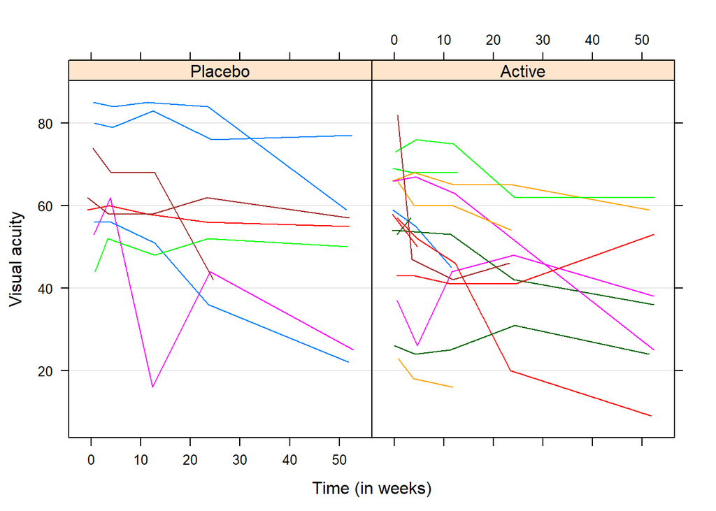

```r
library(lattice)
data(armd.wide, armd0, package = "nlmeU") # Data loaded
armd0.subset <- subset(armd0, as.numeric(subject) %in% seq(1, 240, 10))
xy1 <- xyplot(visual ~ jitter(time) | treat.f,  groups = subject,  data = armd0.subset,
                                 type = "l", lty = 1)
update(xy1, xlab = "Time (in weeks)", ylab = "Visual acuity",  grid = "h")
```

1. Based on the above plots, what observations can be made about visual acuity?

Based on the plots shown above, several observations can be made:

- In general, visual acuity tends to decrease in time.
- For some patients, a linear decrease of visual acuity over time can be observed,but there are also patients for whom individual profiles strongly deviate from a linear trend.
- Visual acuity measurements adjacent in time are fairly well correlated, with the correlation decreasing with an increasing distance in time.
- Visual acuity at baseline seems to, at least partially, determine the overall level of the post-randomization measurements.
- There are patients for whom several measurements are missing.

*Notes on Code* First, we load data to be used for exploration from the nlmeU package. Note that the code used to create figure employs the function `xyplot()` from the package `lattice` (Sarkar, 2008). The function is applied to the subset of the data frame `armd0` . The formula used in the syntax indicates that the variables visual and time are to be used on the `y` and `x`-axis, respectively. These variables are plotted against each other in separate panels for different values of the `treat.f` factor. Within each panel, data points are grouped for each subject and connected using solid lines. The function `jitter()` is used to add a small amount of noise to the variable time, thereby reducing the number of overlapping points.

2. Patterns of Missing Data

First, we check the number and patterns of missing visual acuity measurements. Toward this end, we use the data frame armd.wide. The data frame contains the `factor miss.pat` that indicates which of the four post-randomization measurements are missing for a particular patient. For example, the pattern `--X-` indicates that the only missing measurement was at the third post-randomization timepoint, i.e., at 24 weeks. What can we see from this table?

```r
table(armd.wide$miss.pat)
```

```
##
## ---- ---X --X- --XX -XX- -XXX X--- X-XX XXXX
##  188   24    4    8    1    6    2    1    6
```

From the displayed results, we can conclude that, for instance, there were 188 patients for whom all four postrandomization visual acuity measurements were obtained. On the other hand, there were six patients for whom the four measurements were missing.

3. Mean value Profiles:

In this question, we investigate the number of missing values and calculate the sample means of visual acuity measurements for different visits and treatment groups. We wish to first count the number of nonmissing elements and then to look at means and medians across times and treatment groups.

[output not shown]

We can see that once again we use the `tapply()` function. This time we are looking at `visual` again but this time instead of counts we wish to calculate the mean and median. At baseline there was little difference between the groups. However as time advances both groups decrease in mean and there are higher means/medians in the placebo group.

4. Next we wish you look at box-whisker plots of `visual` across the times and treatments. What can we tell from this analysis?

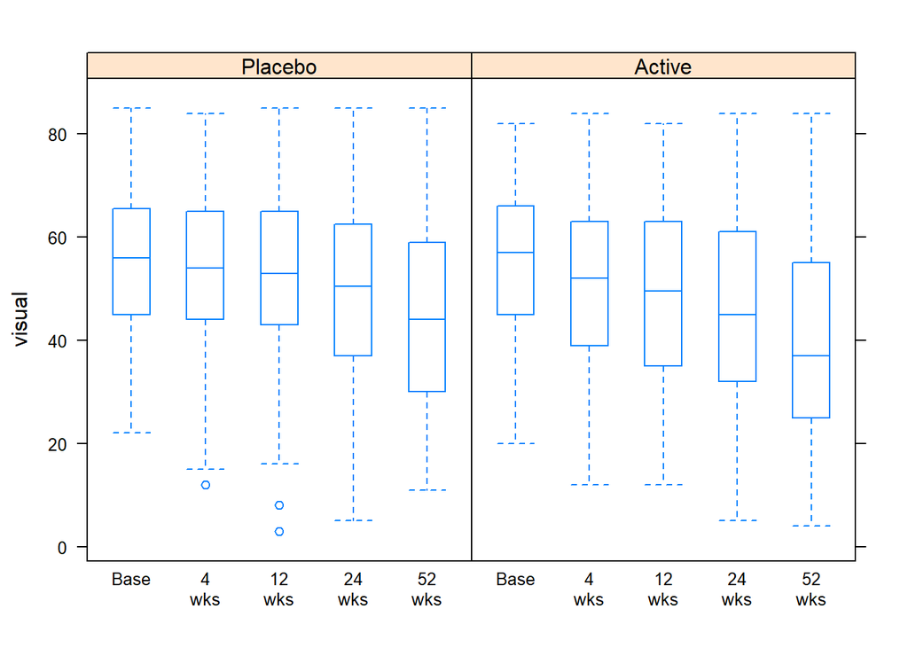

```r
library(lattice)
bw1 <- bwplot(visual ~ time.f | treat.f, data = armd0)
xlims <- c("Base", "4\nwks", "12\nwks", "24\nwks", "52\nwks")
update(bw1, xlim = xlims, pch = "|") # Final plot
```

The box-and-whiskers plots illustrate the patterns implied by the sample means and medians. The decrease of the mean values in time is clearly seen for both treatment groups. It is more pronounced for the active treatment arm. As there was a slightly higher dropout in that arm, a possible explanation could be that patients whose visual acuity improved dropped out of the study. In such case, a faster progression of the disease in that treatment arm would be observed.

5. Sample Variances and Correlations of Visual Acuity Measurements.
1. We wish to first of all only consider patients that have a monoton missing data patterns. This means we wish to have that if a patient misses time 2, they also miss time 3 and time 4. We do not want patients who miss a time and come back again later.

```r
mnt.pat<-  c("----", "---X", "--XX", "-XXX", "XXXX")# Monotone patterns
armd.wide.mnt <-  subset(armd.wide, miss.pat %in% mnt.pat) # Data subset
dim(armd.wide.mnt) # Number of rows and cols
```

```
## [1] 232  10
```

```r
levels(armd.wide.mnt$miss.pat)
```

```
## [1] "----" "---X" "--X-" "--XX" "-XX-" "-XXX" "X---" "X-XX" "XXXX"
```

2. We then wish to remove the unused levels from the `miss.pat` factor:

```r
armd.wide.mnt1 <- within(armd.wide.mnt,
          {
            miss.pat <- factor(miss.pat, levels=mnt.pat)
          })
levels(armd.wide.mnt1$miss.pat)
```

```
## [1] "----" "---X" "--XX" "-XXX" "XXXX"
```

With this code we remove the levels that we do not use so that we do not have a large number of extra columns in a table. This step does not need to be done but it can clean up the data better.

3. We can then count the number of people with these different monotone patterns.

```r
with(armd.wide.mnt1,
      {
      fl <- list(treat.f, miss.pat) # List of "by" factors
      tapply(subject, fl, FUN=function(x) length(x[!is.na(x)]))
      })
```

```
##         ---- ---X --XX -XXX XXXX
## Placebo  102    9    3    1    1
## Active    86   15    5    5    5
```

We again apply the function to count for non-missing values in each category.

6. Variance and Covariance Matrices.

We mentioned in notes that when you work with this kind of time data that there are correlations between measurements. We will explore these.

```r
visual.x <- subset(armd.wide, select = c(visual0:visual52))
(varx <- var(visual.x, use = "complete.obs")) # Var-cov mtx
```

```
##           visual0  visual4 visual12 visual24 visual52
## visual0  220.3055 206.7096 196.2439 193.3099 152.7141
## visual4  206.7096 246.2204 224.7933 221.2677 179.2284
## visual12 196.2439 224.7933 286.2072 257.7738 222.6830
## visual24 193.3099 221.2677 257.7738 334.4456 285.2327
## visual52 152.7141 179.2284 222.6830 285.2327 347.4311
```

```r
print(cor(visual.x, use = "complete.obs"), digits = 2)
```

```
##          visual0 visual4 visual12 visual24 visual52
## visual0     1.00    0.89     0.78     0.71     0.55
## visual4     0.89    1.00     0.85     0.77     0.61
## visual12    0.78    0.85     1.00     0.83     0.71
## visual24    0.71    0.77     0.83     1.00     0.84
## visual52    0.55    0.61     0.71     0.84     1.00
```

```r
diag(varx) # Var-cov diagonal elements
```

```
##  visual0  visual4 visual12 visual24 visual52
## 220.3055 246.2204 286.2072 334.4456 347.4311
```

```r
cov2cor(varx) # Corr mtx (alternative way)
```

```
##            visual0   visual4  visual12  visual24  visual52
## visual0  1.0000000 0.8875360 0.7815256 0.7121620 0.5519911
## visual4  0.8875360 1.0000000 0.8468003 0.7710692 0.6127882
## visual12 0.7815256 0.8468003 1.0000000 0.8331742 0.7061752
## visual24 0.7121620 0.7710692 0.8331742 1.0000000 0.8367625
## visual52 0.5519911 0.6127882 0.7061752 0.8367625 1.0000000
```

We can look at this data and we first of all just grab data that is of `visual` measurements. We then find the variance-covariance matrix over these measurements only using complete observations. We also display another way to get the correlation matrix as well.

6. Create a scatter plot matrix of correlation among times.

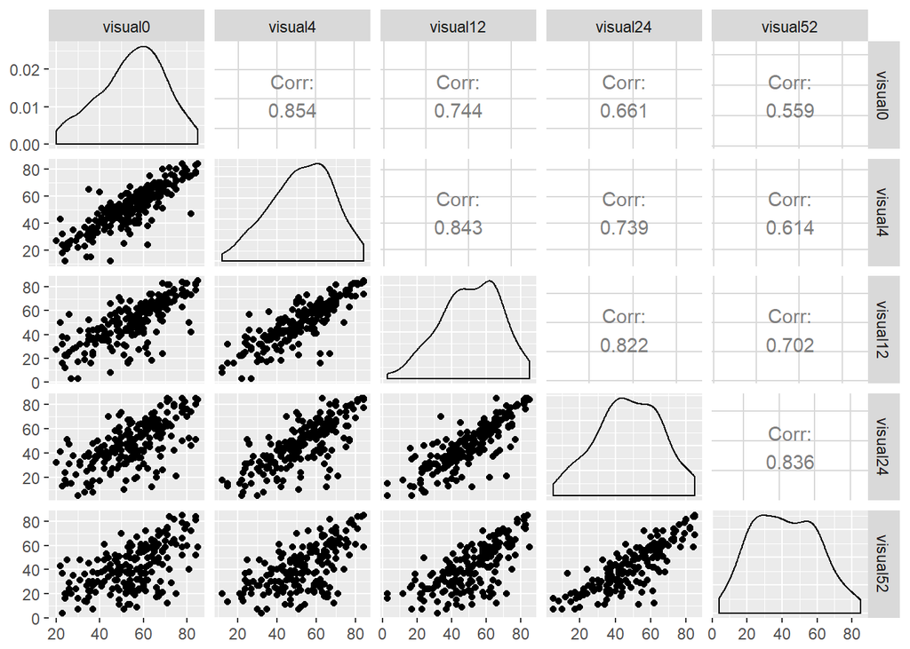

```r
library(GGally)
ggpairs(visual.x)
```

With this command we can create a scatter plot amtrix of the various visual measurements over time. We can also see the correlation statistics as well as a density curve for what the data looks like. We see they appear to be fairly normal. Also note that time measurements close together are more correlated that time measurements that are further apart. This makes sense but try and get a clear understanding of why.

7. Linear Mixed Effects Model.

we first need the data to be in long format:

```r
library(tidyverse)
armd.long <- armd.wide %>%
  gather(key="month", "visual", 4:8) %>%
  mutate(month = as.numeric(gsub("visual", "", month)))
```

```r
library(lme4)
mod.int <- lmer(visual~ 1 + month + (1|subject), data= armd.long)
mod.slope <- lmer(visual~ 1 + month + (month|subject), data= armd.long)
mod.full <- lmer(visual~ 1 + month + (1+month|subject), data= armd.long)


summary(mod.int)
```

```
## Linear mixed model fit by REML ['lmerMod']
## Formula: visual ~ 1 + month + (1 | subject)
##    Data: armd.long
##
## REML criterion at convergence: 8584
##
## Scaled residuals:
##     Min      1Q  Median      3Q     Max
## -3.9833 -0.4498  0.0125  0.5404  2.9482
##
## Random effects:
##  Groups   Name        Variance Std.Dev.
##  subject  (Intercept) 211.37   14.539
##  Residual              77.87    8.824
## Number of obs: 1107, groups:  subject, 240
##
## Fixed effects:
##             Estimate Std. Error t value
## (Intercept)  54.0947     1.0082   53.66
## month        -0.2501     0.0149  -16.78
##
## Correlation of Fixed Effects:
##       (Intr)
## month -0.242
```

```r
summary(mod.slope)
```

```
## Linear mixed model fit by REML ['lmerMod']
## Formula: visual ~ 1 + month + (month | subject)
##    Data: armd.long
##
## REML criterion at convergence: 8430.7
##
## Scaled residuals:
##     Min      1Q  Median      3Q     Max
## -3.9610 -0.3600  0.0290  0.4439  3.2362
##
## Random effects:
##  Groups   Name        Variance  Std.Dev. Corr
##  subject  (Intercept) 214.17887 14.6349
##           month         0.08364  0.2892  -0.12
##  Residual              47.15623  6.8670
## Number of obs: 1107, groups:  subject, 240
##
## Fixed effects:
##             Estimate Std. Error t value
## (Intercept) 54.15832    0.98797   54.82
## month       -0.25840    0.02303  -11.22
##
## Correlation of Fixed Effects:
##       (Intr)
## month -0.196
```

```r
summary(mod.full)
```

```
## Linear mixed model fit by REML ['lmerMod']
## Formula: visual ~ 1 + month + (1 + month | subject)
##    Data: armd.long
##
## REML criterion at convergence: 8430.7
##
## Scaled residuals:
##     Min      1Q  Median      3Q     Max
## -3.9610 -0.3600  0.0290  0.4439  3.2362
##
## Random effects:
##  Groups   Name        Variance  Std.Dev. Corr
##  subject  (Intercept) 214.17887 14.6349
##           month         0.08364  0.2892  -0.12
##  Residual              47.15623  6.8670
## Number of obs: 1107, groups:  subject, 240
##
## Fixed effects:
##             Estimate Std. Error t value
## (Intercept) 54.15832    0.98797   54.82
## month       -0.25840    0.02303  -11.22
##
## Correlation of Fixed Effects:
##       (Intr)
## month -0.196
```

```r
m1 <- update(mod.int, REML=F)
m2 <- update(mod.slope, REML=F)
m3 <- update(mod.full, REML=F)
anova(m1,m2,m3)
```

```
## Data: armd.long
## Models:
## m1: visual ~ 1 + month + (1 | subject)
## m2: visual ~ 1 + month + (month | subject)
## m3: visual ~ 1 + month + (1 + month | subject)
##    Df    AIC    BIC  logLik deviance Chisq Chi Df Pr(>Chisq)
## m1  4 8587.2 8607.2 -4289.6   8579.2
## m2  6 8438.8 8468.8 -4213.4   8426.8 152.4      2     <2e-16 ***
## m3  6 8438.8 8468.8 -4213.4   8426.8   0.0      0          1
## ---
## Signif. codes:  0 '***' 0.001 '**' 0.01 '*' 0.05 '.' 0.1 ' ' 1
```

#### Lab Source

This lab was adopted from [Linear Mixed-Effect Models Using R: A Step-by-step approach](http://www.springer.com/us/book/9781461438991). You can find this at the Brown library online for free. The code and much of the explanations are taken from this.